# AI Trading Strategy

## Objective

The objective of this project is to develop an AI-driven intraday trading strategy using reinforcement learning and deep learning techniques. The focus is on leveraging the IVV ETF data to create models that predict short-term market movements and optimize trading decisions.

## Team Composition

- Emil Alizada
- Ritwick Haldar
- Muhammad Zubair Ahmed Khan

```python
%run main.py
```

## Step 1: Setting Environment Variables

Set environment variables to control TensorFlow and matplotlib behaviors, ensuring that TensorFlow runs on the CPU and that matplotlib runs in an offscreen mode.

```python
# Set environment variables
np.seterr(divide='ignore', invalid='ignore')
os.environ['TF_ENABLE_ONEDNN_OPTS'] = '0'
os.environ['TF_CPP_MIN_LOG_LEVEL'] = '3'  # Suppress all logs except errors
os.environ['CUDA_VISIBLE_DEVICES'] = '-1'  # Force TensorFlow to use CPU
os.environ['QT_QPA_PLATFORM'] = 'offscreen'  # Suppress Qt backend issues
```

## Step 2: Load Data

Load the training and validation datasets for the IVV ETF. We use a subset of the data for testing purposes.

```python
# Load data
train_data = pd.read_csv('IVV_1m_training.csv') # Using a subset for testing
val_data = pd.read_csv('IVV_1m_validation.csv')  # Using a subset for testing
test_data = pd.read_csv('IVV_test_sample.csv') # Using a subset for testing
```

## Step 3: Data Preprocessing

Preprocess the data by adding technical indicators such as Simple Moving Average (SMA), Relative Strength Index (RSI), Moving Average Convergence Divergence (MACD), and Bollinger Bands.

```python
def preprocess_data(data):
    data['DateTime'] = pd.to_datetime(data['DateTime'])
    data.set_index('DateTime', inplace=True)
    data['SMA'] = data['Close'].rolling(window=20).mean()
    data['RSI'] = compute_RSI(data['Close'], 14)
    data['MACD'] = compute_MACD(data['Close'])
    data['BB_upper'], data['BB_middle'], data['BB_lower'] = compute_Bollinger_Bands(data['Close'])
    data.dropna(inplace=True)
    return data

def compute_RSI(data, window):
    diff = data.diff(1)
    gain = diff.clip(lower=0)
    loss = -1 * diff.clip(upper=0)
    avg_gain = gain.rolling(window=window).mean()
    avg_loss = loss.rolling(window=window).mean()
    rs = avg_gain / avg_loss
    rsi = 100 - (100 / (1 + rs))
    return rsi

def compute_MACD(data, slow=26, fast=12, signal=9):
    ema_fast = data.ewm(span=fast, min_periods=fast).mean()
    ema_slow = data.ewm(span=slow, min_periods=slow).mean()
    macd = ema_fast - ema_slow
    signal_line = macd.ewm(span=signal, min_periods=signal).mean()
    return macd - signal_line

def compute_Bollinger_Bands(data, window=20, num_std=2):
    rolling_mean = data.rolling(window=window).mean()
    rolling_std = data.rolling(window=window).std()
    upper_band = rolling_mean + (rolling_std * num_std)
    lower_band = rolling_mean - (rolling_std * num_std)
    return upper_band, rolling_mean, lower_band

train_data = preprocess_data(train_data)
val_data = preprocess_data(val_data)
test_data = preprocess_data(test_data)
```

## Step 4: Data Normalization

Normalize the data using `StandardScaler` to ensure that all features have a mean of 0 and a standard deviation of 1, which is essential for training the LSTM model effectively.

```python
# Normalize data
scaler = StandardScaler()
train_data_scaled = scaler.fit_transform(train_data)
val_data_scaled = scaler.transform(val_data)
test_data_scaled = scaler.transform(test_data)
joblib.dump(scaler, "scaler.joblib")
```

```
['scaler.joblib']
```

## Step 5: Breakout Strategy

Implement a breakout strategy to label the data with buy and sell signals. This strategy identifies potential breakout points based on the highest and lowest prices over a specified look-back period.

```python
def breakout_strategy(data, lookback=20):
    data['High_max'] = data['High'].rolling(window=lookback).max()
    data['Low_min'] = data['Low'].rolling(window=lookback).min()
    data['Buy'] = np.where(data['Close'] > data['High_max'].shift(1), 1, 0)
    data['Sell'] = np.where(data['Close'] < data['Low_min'].shift(1), 1, 0)
    return data

train_data = breakout_strategy(train_data)
val_data = breakout_strategy(val_data)
test_data = breakout_strategy(test_data)
```

## Step 6: Prepare Data for LSTM

Create a dataset for the LSTM model with the specified look-back period. This step involves reshaping the data into sequences that the LSTM model can process.

```python
def create_dataset(data, look_back=1):
    X, Y = [], []
    for i in range(len(data) - look_back - 1):
        a = data[i:(i + look_back), :-1]
        X.append(a)
        Y.append(data[i + look_back, -1])
    return np.array(X), np.array(Y)

look_back = 60  # 60 minutes look back
X_train, y_train = create_dataset(train_data_scaled, look_back)
X_val, y_val = create_dataset(val_data_scaled, look_back)
X_test, y_test = create_dataset(test_data_scaled, look_back)


# Combine training and validation data
X_train_combined = np.concatenate((X_train, X_val), axis=0)
y_train_combined = np.concatenate((y_train, y_val), axis=0)
```

## Step 7: Build and Train LSTM Model

Build the LSTM model using Keras, compile it with the Adam optimizer and mean squared error loss function, and then train the model on the prepared training data.

```python
# Build LSTM model
model = Sequential()
model.add(LSTM(50, return_sequences=True, input_shape=(look_back, X_train.shape[2])))
model.add(LSTM(50, return_sequences=False))
model.add(Dropout(0.2))
model.add(Dense(25))
model.add(Dense(1))

model.compile(optimizer='adam', loss='mean_squared_error')
model.fit(X_train_combined, y_train_combined, batch_size=64, epochs=50)

# Save the model using Keras' save method
model.save('lstm_model_combined_data.h5')
print("LSTM model saved successfully.")

# Function to calculate RMSE
def calculate_rmse(predictions, targets):
    mse = mean_squared_error(targets, predictions)
    rmse = math.sqrt(mse)
    return rmse

# Make predictions
train_predictions = model.predict(X_train)
val_predictions = model.predict(X_val)
test_predictions = model.predict(X_test)

# Calculate RMSE for training, validation, and test data
train_rmse = calculate_rmse(train_predictions, y_train)
val_rmse = calculate_rmse(val_predictions, y_val)
test_rmse = calculate_rmse(test_predictions, y_test)

print("RMSE for Training Data:", train_rmse)
print("RMSE for Validation Data:", val_rmse)
print("RMSE for Test Data:", test_rmse)
```

```
c:\Users\Zubair Khan\AppData\Local\Programs\Python\Python312\Lib\site-packages\keras\src\layers\rnn\rnn.py:204: UserWarning: Do not pass an `input_shape`/`input_dim` argument to a layer. When using Sequential models, prefer using an `Input(shape)` object as the first layer in the model instead.
  super().__init__(**kwargs)
```

[output not shown]

```
WARNING:absl:You are saving your model as an HDF5 file via `model.save()` or `keras.saving.save_model(model)`. This file format is considered legacy. We recommend using instead the native Keras format, e.g. `model.save('my_model.keras')` or `keras.saving.save_model(model, 'my_model.keras')`.
```

```
LSTM model saved successfully.
30561/30561 ━━━━━━━━━━━━━━━━━━━━ 161s 5ms/step
9142/9142 ━━━━━━━━━━━━━━━━━━━━ 49s 5ms/step
12110/12110 ━━━━━━━━━━━━━━━━━━━━ 68s 6ms/step
RMSE for Training Data: 0.00558818175402838
RMSE for Validation Data: 0.04130316377347658
RMSE for Test Data: 1.818082627216945
```

## Step 8: Define Trading Environment

Create a custom trading environment using the OpenAI Gym framework. This environment simulates trading activities and evaluates the performance of the reinforcement learning agent.

```python
# Load the LSTM model
lstm_model = load_model('lstm_model_combined_data.h5')

# Load the scaler
scaler = joblib.load("scaler.joblib")

look_back = 10  # Assuming a look-back window of 10

class TradingEnv(gym.Env):
    def __init__(self, model, scaler, data, initial_balance=10000, stop_loss=0.005, take_profit=0.01, min_trades=2, max_trades=8, trading_cost=0.0001):
        super(TradingEnv, self).__init__()
        self.model = model
        self.scaler = scaler
        self.data = data
        self.current_step = 0
        self.initial_balance = initial_balance
        self.balance = initial_balance
        self.stop_loss = stop_loss
        self.take_profit = take_profit
        self.position = 0  # 0: no position, 1: long, -1: short
        self.entry_price_long = 0
        self.entry_price_short = 0
        self.trades_per_day = 0
        self.min_trades = min_trades
        self.max_trades = max_trades
        self.current_day = self.current_step
        self.daily_trades = []
        self.daily_profits = []
        self.trading_cost = trading_cost  # Trading cost percentage

        self.action_space = spaces.Discrete(3)  # buy, sell, hold
        self.observation_space = spaces.Box(low=-np.inf, high=np.inf, shape=(look_back, data.shape[1]), dtype=np.float32)


    def reset(self):
        self.current_step = 0
        self.balance = self.initial_balance
        self.position = 0
        self.entry_price_long = 0
        self.entry_price_short = 0
        self.trades_per_day = 0
        self.daily_trades = []
        self.daily_profits = []
        return self.data[self.current_step:self.current_step + look_back]

    def step(self, action):
        reward = 0
        done = self.current_step >= len(self.data) - look_back - 1

        # Take action
        current_price = self.data[self.current_step][-1]
        if action == 1:  # buy
            if self.position == 0 and self.trades_per_day < self.max_trades:
                self.position = 1
                self.entry_price_long = current_price
                self.trades_per_day += 1
            elif self.position == -1:  # if already short, open long too
                self.position = 2  # indicating both long and short positions
                self.entry_price_long = current_price
        elif action == 2:  # sell
            if self.position == 0 and self.trades_per_day < self.max_trades:
                self.position = -1
                self.entry_price_short = current_price
                self.trades_per_day += 1
            elif self.position == 1:  # if already long, open short too
                self.position = 2  # indicating both long and short positions
                self.entry_price_short = current_price
        elif action == 0:  # hold
            pass

        # Randomize trade size between 3000 and 4000
        trade_size = np.random.uniform(3000, 4000)

        # Check stop-loss and take-profit conditions
        if self.position == 1:
            if (current_price <= self.entry_price_long * (1 - self.stop_loss)) or (current_price >= self.entry_price_long * (1 + self.take_profit)):
                trade_value = min(self.balance, trade_size, self.balance * (1 - self.trading_cost))  # Adjusting for trading cost
                reward = (current_price - self.entry_price_long) * (trade_value / self.entry_price_long)
                self.balance += reward
                self.position = 0
        elif self.position == -1:
            if (current_price >= self.entry_price_short * (1 + self.stop_loss)) or (current_price <= self.entry_price_short * (1 - self.take_profit)):
                trade_value = min(self.balance, trade_size, self.balance * (1 - self.trading_cost))  # Adjusting for trading cost
                reward = (self.entry_price_short - current_price) * (trade_value / self.entry_price_short)
                self.balance += reward
                self.position = 0
        elif self.position == 2:
            # Check long position
            if (current_price <= self.entry_price_long * (1 - self.stop_loss)) or (current_price >= self.entry_price_long * (1 + self.take_profit)):
                trade_value_long = min(self.balance, trade_size, self.balance * (1 - self.trading_cost))  # Adjusting for trading cost
                reward_long = (current_price - self.entry_price_long) * (trade_value_long / self.entry_price_long)
                if reward_long < 0:  # if long is in loss, close it
                    self.position = -1
                else:  # if long is in profit, open another long
                    self.balance += reward_long
                    reward += reward_long
                    self.position = 1  # keep the short position open
            # Check short position
            if (current_price >= self.entry_price_short * (1 + self.stop_loss)) or (current_price <= self.entry_price_short * (1 - self.take_profit)):
                trade_value_short = min(self.balance, trade_size, self.balance * (1 - self.trading_cost))  # Adjusting for trading cost
                reward_short = (self.entry_price_short - current_price) * (trade_value_short / self.entry_price_short)
                if reward_short < 0:  # if short is in loss, close it
                    self.position = 1
                else:  # if short is in profit, open another short
                    self.balance += reward_short
                    reward += reward_short
                    self.position = -1  # keep the long position open

        self.current_step += 1

        # Check if it's a new day
        if self.current_step % 1440 == 0:  # Assuming one day is 1440 minutes
            if self.trades_per_day < self.min_trades:
                reward -= 100  # Penalty for not meeting the minimum trades requirement
            if self.position != 0:
                # Close position at market price at the end of the day
                if self.position == 1:
                    trade_value = min(self.balance, trade_size, self.balance * (1 - self.trading_cost))  # Adjusting for trading cost
                    reward += (current_price - self.entry_price_long) * (trade_value / self.entry_price_long)
                elif self.position == -1:
                    trade_value = min(self.balance, trade_size, self.balance * (1 - self.trading_cost))  # Adjusting for trading cost
                    reward += (self.entry_price_short - current_price) * (trade_value / self.entry_price_short)
                reward -= abs(reward * self.trading_cost)  # Deduct trading cost
                self.balance += reward
                self.position = 0
            self.daily_trades.append(self.trades_per_day)
            self.daily_profits.append(self.balance - self.initial_balance)
            self.trades_per_day = 0

        state = self.data[self.current_step:self.current_step + look_back]
        return state, reward, done, {}
```

```
WARNING:absl:Compiled the loaded model, but the compiled metrics have yet to be built. `model.compile_metrics` will be empty until you train or evaluate the model.
```

```
Using cpu device
Wrapping the env with a `Monitor` wrapper
Wrapping the env in a DummyVecEnv.
```

[output not shown]

[output cut: 14824 more lines]

```
Date and Time: 2023-12-13 19:22:00+00:00
Action: Buy
Reward: 42.62139245427824
Trade Details:
Date and Time: 2023-12-14 14:46:00+00:00
Action: Buy
Reward: 35.33125359666691
Trade Details:
Date and Time: 2023-12-14 14:47:00+00:00
Action: Sell
Reward: 48.07533273870845
Trade Details:
Date and Time: 2023-12-14 14:48:00+00:00
Action: Buy
Reward: 44.68010002668069
```

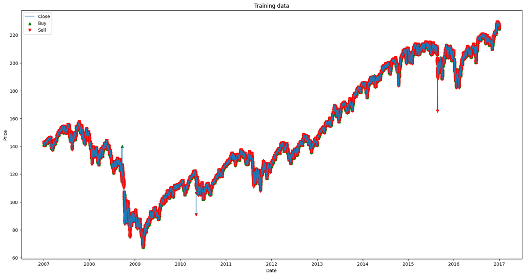

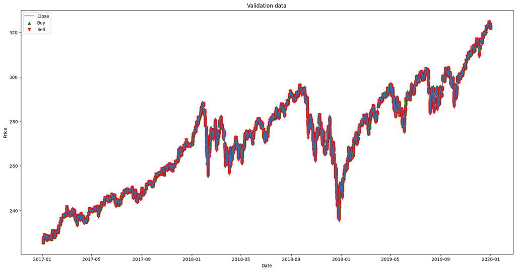

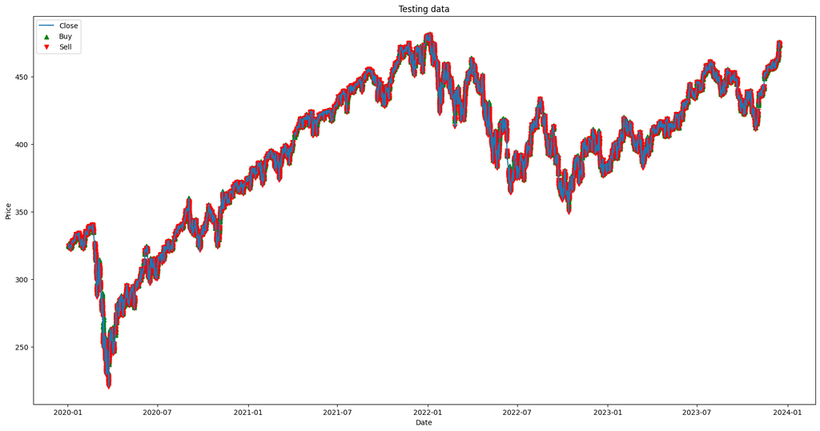

[figure not shown]

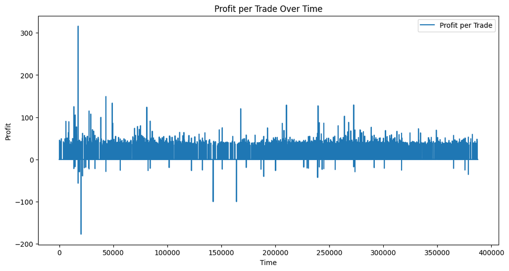

```
Plots saved successfully.
Success trades: 3649
Net Profit: 143708.98587296612
Net Worth: 153708.98587296612
Balance: 153745.40097911507
Trades per day: 6.434944237918216
Total trades: 3700
```

```
{'divide': 'ignore', 'over': 'warn', 'under': 'ignore', 'invalid': 'ignore'}
```

```python
%matplotlib inline

env = TradingEnv(model=lstm_model, scaler=scaler, data=test_data_scaled)
val_env = TradingEnv(model=lstm_model, scaler=scaler, data=test_data_scaled)
test_env = TradingEnv(model=lstm_model, scaler=scaler, data=test_data_scaled)

# Train and save the PPO model if it doesn't already exist
drl_model = PPO('MlpPolicy', env, verbose=1)
drl_model.learn(total_timesteps=10000)
drl_model.save("drl_trading_model")

# Load the trained model
drl_model = PPO.load("drl_trading_model")

# Evaluation on testing dataset
state = test_env.reset()
done = False
cumulative_returns = []
actions_test = []
profits_test = []
initial_balance_test = 10000  # Starting with $10,000
successful_trades = 0
unsuccessful_trades = 0
total_trades = 0

current_balance_test = initial_balance_test
net_profit = 0
total_trade_amount = 0

while not done:
    action = np.random.randint(0, 3)  # Replace with your DRL model's prediction
    state, reward, done, info = test_env.step(action)
    current_balance_test += reward
    profits_test.append(reward)
    cumulative_returns.append(current_balance_test)
    actions_test.append(action)

    # Update successful trades count
    if reward > 0:
        successful_trades += 1
    elif reward < 0:  # Update unsuccessful trades count
        unsuccessful_trades += 1
    total_trades = successful_trades + unsuccessful_trades  # Update total trades

    # Update net profit and total trade amount
    if reward != 0:
        net_profit += reward
        total_trade_amount += np.abs(reward)

    # Print trade details
    if reward != 0:
        current_date_time = test_data.index[test_env.current_step]
        print(f"Trade Details:")
        print(f"Date and Time: {current_date_time}")
        print(f"Action: {'Buy' if action == 1 else 'Sell'}")
        print(f"Reward: {reward}")

# Calculate cumulative return in percentage
#cumulative_return_test = np.array(cumulative_return_test)
#cumulative_return_test = (cumulative_return_test - initial_balance_test) / initial_balance_test * 100  # Percentage return

# Example of detailed output

net_worth = initial_balance_test + net_profit
balance = test_env.balance
trades_per_day = np.mean(test_env.daily_trades)

# Calculate metrics
# Calculate cumulative returns (%)
final_balance = net_worth  # Assuming net_worth represents the final balance
#cumulative_returns = np.array(cumulative_returns)
cumulative_returns = np.array(cumulative_returns)
cumulative_returns = ((cumulative_returns - initial_balance_test) / initial_balance_test) * 100


# Calculate success accuracy
success_trades = (total_trades - unsuccessful_trades)

# Store results in a DataFrame
results = pd.DataFrame({
    'cumulative_returns': cumulative_returns,
    'actions_test': actions_test,
    'profits_test': profits_test
})



# Plotting buy and sell signals on training data
plt.figure(figsize=(20, 10))
plt.plot(train_data.index, train_data['Close'], label='Close')
plt.scatter(train_data.index[train_data['Buy'] == 1], train_data['Close'][train_data['Buy'] == 1], marker='^', color='g', label='Buy', alpha=1)
plt.scatter(train_data.index[train_data['Sell'] == 1], train_data['Close'][train_data['Sell'] == 1], marker='v', color='r', label='Sell', alpha=1)
plt.title('Training data')
plt.xlabel('Date')
plt.ylabel('Price')
plt.legend()
plt.show()  # Show the plot

# Plotting buy and sell signals on validation data
plt.figure(figsize=(20, 10))
plt.plot(val_data.index, val_data['Close'], label='Close')
plt.scatter(val_data.index[val_data['Buy'] == 1], val_data['Close'][val_data['Buy'] == 1], marker='^', color='g', label='Buy', alpha=1)
plt.scatter(val_data.index[val_data['Sell'] == 1], val_data['Close'][val_data['Sell'] == 1], marker='v', color='r', label='Sell', alpha=1)
plt.title('Validation data')
plt.xlabel('Date')
plt.ylabel('Price')
plt.legend()
plt.show()  # Show the plot


# Plotting buy and sell signals on testing data
plt.figure(figsize=(20, 10))
plt.plot(test_data.index, test_data['Close'], label='Close')
plt.scatter(test_data.index[test_data['Buy'] == 1], test_data['Close'][test_data['Buy'] == 1], marker='^', color='g', label='Buy', alpha=1)
plt.scatter(test_data.index[test_data['Sell'] == 1], test_data['Close'][test_data['Sell'] == 1], marker='v', color='r', label='Sell', alpha=1)
plt.title('Testing data')
plt.xlabel('Date')
plt.ylabel('Price')
plt.legend()
plt.show()  # Show the plot


# Plot actions taken by the agent
plt.figure(figsize=(12, 6))
plt.plot(results.index, results['actions_test'], label='Actions')
plt.xlabel('Time')
plt.ylabel('Action')
plt.title('Actions Taken by the Trading Agent')
plt.legend()
plt.show()  # Show the plot

# Plot profits per trade
plt.figure(figsize=(12, 6))
plt.plot(results.index, results['profits_test'], label='Profit per Trade')
plt.xlabel('Time')
plt.ylabel('Profit')
plt.title('Profit per Trade Over Time')
plt.legend()
plt.show()  # Show the plot



# Example of detailed output
net_worth = initial_balance_test + net_profit
balance = test_env.balance
trades_per_day = np.mean(test_env.daily_trades)

print("Plots saved successfully.")
print(f"Success trades: {success_trades}")


print(f"Net Profit: {net_profit}")
print(f"Net Worth: {net_worth}")
print(f"Balance: {balance}")
print(f"Trades per day: {trades_per_day}")
print(f"Total trades: {total_trades}")


np.seterr(divide='warn', invalid='warn')
```

## Step 10: Calculate Metrics

```python
# Compounded annual return (%)
start_date = pd.to_datetime(results.index[0])
end_date = pd.to_datetime(results.index[-1])
num_days = (end_date - start_date).days
num_years = num_days / 365.25 if num_days > 365.25 else 1  # Prevent division by zero
compounded_annual_return = ((net_worth / initial_balance_test) ** (1 / num_years) - 1) * 100

# Annual volatility
annual_volatility = np.std(results['cumulative_returns'].pct_change().dropna()) * np.sqrt(252) * 100  # Assuming 252 trading days in a year

# VaR Hist (Value at Risk)
var_hist = np.percentile(results['cumulative_returns'], 5)  # 5% VaR

# CVaR Hist (Conditional Value at Risk)
cvar_hist = results['cumulative_returns'][results['cumulative_returns'] <= var_hist].mean()

# Sharpe Ratio
daily_returns = results['cumulative_returns'].pct_change().dropna()
sharpe_ratio = (daily_returns.mean() / daily_returns.std()) * np.sqrt(252)  # Assuming 252 trading days in a year

# Sortino Ratio
downside_returns = daily_returns[daily_returns < 0]
sortino_ratio = (daily_returns.mean() / downside_returns.std()) * np.sqrt(252)

# Print or use the calculated metrics as needed
print("Cumulative Returns (%):", cumulative_returns)
print("Compounded Annual Return (%):", compounded_annual_return)
print("Annual Volatility:", annual_volatility)
print("VaR Hist:", var_hist)
print("CVaR Hist:", cvar_hist)
print("Sharpe Ratio:", sharpe_ratio)
print("Sortino Ratio:", sortino_ratio)

# Define the path for the output text file
output_file_path = "trading_output.txt"

# Open the text file in write mode
with open(output_file_path, "w") as output_file:
    # Write the output data to the text file
    output_file.write("Output Data:\n")

    # Write any specific information or results you want to include
    output_file.write("Cumulative Returns (%): {}\n".format(cumulative_returns))
    output_file.write("Compounded Annual Return (%): {}\n".format(compounded_annual_return))
    output_file.write("Annual Volatility: {}\n".format(annual_volatility))
    output_file.write("VaR Hist: {}\n".format(var_hist))
    output_file.write("CVaR Hist: {}\n".format(cvar_hist))
    output_file.write("Sharpe Ratio: {}\n".format(sharpe_ratio))
    output_file.write("Sortino Ratio: {}\n".format(sortino_ratio))
    output_file.write("Success trades: {}\n".format(success_trades))

    # Write additional information
    output_file.write(f"Net Profit: {net_profit}\n")
    output_file.write(f"Net Worth: {net_worth}\n")
    output_file.write(f"Balance: {balance}\n")
    output_file.write(f"Trades per day: {trades_per_day}\n")
    output_file.write(f"Total trades: {total_trades}\n")
    output_file.write(f"Success trades {success_trades}\n")

    # Write trade details
    output_file.write("Trade Details:\n")
    for i in range(len(profits_test)):
        if profits_test[i] != 0:
            current_date_time = test_data.index[test_env.current_step - len(profits_test) + i + 1]
            trade_action = 'Buy' if actions_test[i] == 1 else 'Sell'
            output_file.write(f"Date and Time: {current_date_time}\n")
            output_file.write(f"Action: {trade_action}\n")
            output_file.write(f"Reward: {profits_test[i]}\n")

# Print a message indicating successful file creation
print("Output data saved to:", output_file_path)
```

```
Cumulative Returns (%): [   0.            0.            0.         ... 1437.08985873 1437.08985873
 1437.08985873]
Compounded Annual Return (%): 1437.0898587296613
Annual Volatility: nan
VaR Hist: 77.90379974527602
CVaR Hist: 32.21839398593478
Sharpe Ratio: nan
Sortino Ratio: inf
Output data saved to: trading_output.txt
```